# TAREA 5

Ignacio Cruz, Joaquin Urria y Fernando Faure

15 de noviembre de 2018

## Pregunta 2

### Parte 1

Descargamos el precio de las acciones de Microsoft y Apple desde enero del 2000 hasta agosto del 2018 con periodicad mensual.

```r
getSymbols(c("MSFT"), src="yahoo", from=as.Date("2000-01-01 "), to=as.Date("2018-08-31"),
           periodicity="monthly")
```

```
## [1] "MSFT"
```

```r
getSymbols("AAPL", src="yahoo", from=as.Date("2000-01-01 "), to=as.Date("2018-08-31"),
                  periodicity="monthly")
```

```
## [1] "AAPL"
```

Juntamos las dos matrices de precios de accion de cada empresa.

```r
for (i in 1:224) {
  MSFT$n[i]=i
}
for (i in 1:224) {
  AAPL$n[i]=i
}

data= merge(AAPL,MSFT, by.x = "n",by.y="n")
```

### Parte 2

Ahora mostraremos los resultados de los distintos estadisticos requeridos y graficaremos los retornos y retorns acumulados.

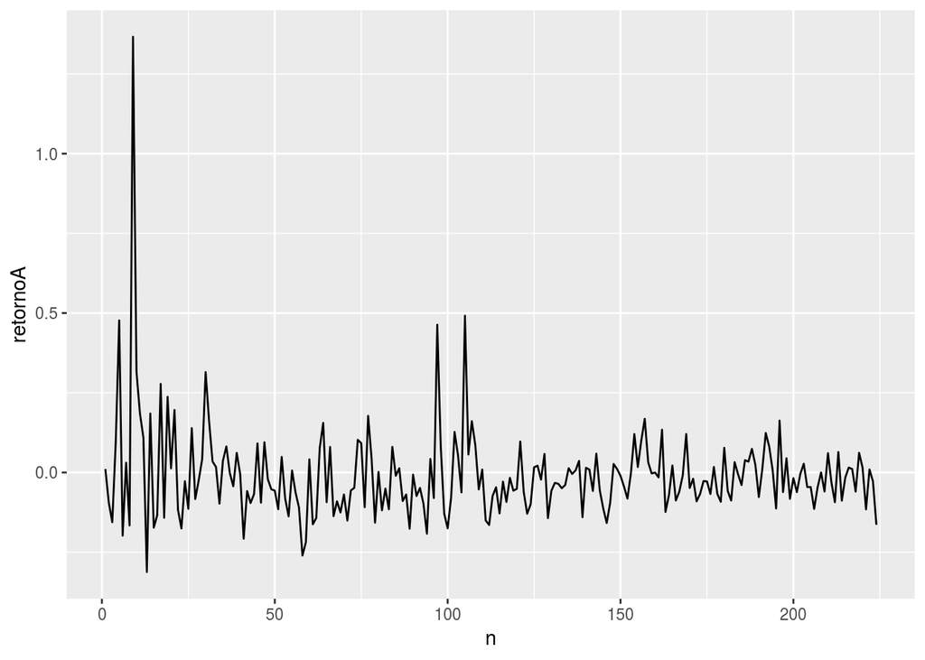

```
##
## [[2]]
##                               [,1]
## Test_Jarque_Bera_para_Retorno "-"
## Hipotesis_Nula                "El retorno sigue una distribución normal"
## Cantidad_de_precios           "224"
## JB.ret.AAPL                   "11620.2867979128"
## Valor_critico_al_90a          "Se rechaza H_0"
## Valor_critico_al_95a          "Se rechaza H_0"
## Valor_critico_al_99a          "Se rechaza H_0"
##
## [[3]]
```

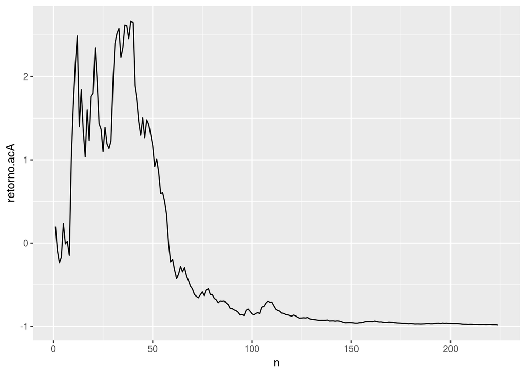

```
##
## [[4]]
##                                         [,1]
## Test_Jarque_Bera_para_Retorno_Acumulado "-"
## Hipotesis__Nula                         "El retorno acumulado sigue una distribución normal"
## Cantidad_de_precios                     "224"
## JB.ret.ac.AAPL                          "5.54572246262723"
## Valor_critico_al_90a                    "Se rechaza H_0"
## Valor_critico_al__95a                   "No se rechaza H_0"
## Valor_critico_al__99a                   "No se rechaza H_0"
##
## [[5]]
```

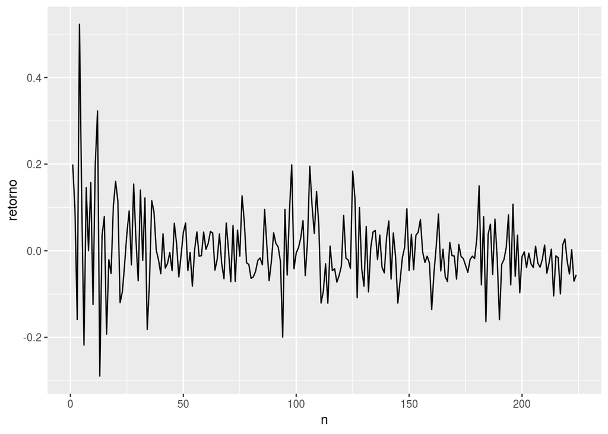

```
##
## [[6]]
##                               [,1]
## Test_Jarque_Bera_para_Retorno "-"
## Hipotesis_Nula                "El retorno sigue una distribución normal"
## Cantidad_de_precios           "224"
## JB.ret.MSFT                   "83.9601797158844"
## Valor_critico_al_90           "Se rechaza H_0"
## Valor_critico_al_95           "Se rechaza H_0"
## Valor_critico_al_99           "Se rechaza H_0"
##
## [[7]]
```

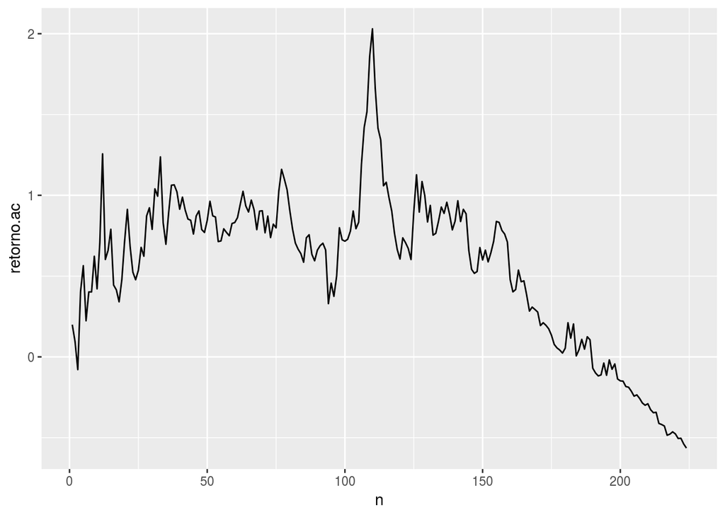

```
##
## [[8]]
##                                         [,1]
## Test_Jarque_Bera_para_Retorno_Acumulado "-"
## Hipotesis__Nula                         "El retorno acumulado sigue una distribución normal"
## Cantidad_de_precios                     "224"
## JB.ret.ac.MSFT                          "83.9863357647004"
## Valor_critico_al_90                     "Se rechaza H_0"
## Valor_critico_al__95                    "Se rechaza H_0"
## Valor_critico_al__99                    "Se rechaza H_0"
```

```r
func.fin(2)
```

## Pregunta 3

### Parte A

Primero definiremos los valores que usaremos para las simulaciones de la pregunta.

```r
set.seed(100)
reps=10000
betas=matrix(NA,nrow=reps,ncol=8)
beta0=2
beta1=2.5
beta2=1
```

Ahora haremos una simulacion para los distintos tamaños de muestras.

```r
n=c(50,100,500,1000)
for(j in 1:length(n)){
  x1<-rnorm(n[j],20,1)
  x2=0.8*x1+rnorm(n[j],0,1)
  for(i in 1:reps){
    u<-rnorm(n[j],0,1)
    y=beta0+beta1*x1+beta2*x2+u
    model=lm(y~x1)
    betas[i,j]=model$coef[1]
    betas[i,j+4]=model$coef[2]

  }
}
```

Obteniendo las siguentes varianzas y esperanzas, tanto de $\beta_{1}$ como de $\beta_{2}$.

```r
betas_df<-data.frame(betas)
apply(betas_df,2,mean)
```

```
##        X1        X2        X3        X4        X5        X6        X7
## -8.556395  2.125223  1.372657  2.408904  3.822035  3.289738  3.328445
##        X8
##  3.279978
```

```r
apply(betas_df,2,var)
```

```
##           X1           X2           X3           X4           X5
## 1.227548e+01 3.573051e+00 7.633733e-01 3.894344e-01 3.041876e-02
##           X6           X7           X8
## 8.788581e-03 1.909278e-03 9.704443e-04
```

### Parte B

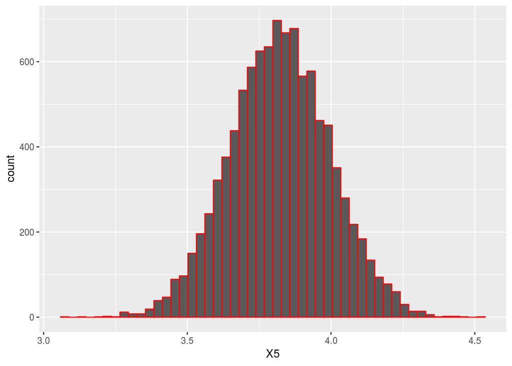

```r
graf1b<-ggplot(betas_df, aes(X5))+geom_histogram(col="red", bins=50)
graf2b<-ggplot(betas_df, aes(X6))+geom_histogram(col="red", bins=50)
graf3b<-ggplot(betas_df, aes(X7))+geom_histogram(col="red", bins=50)
graf4b<-ggplot(betas_df, aes(X8))+geom_histogram(col="red", bins=50)
graf1b
```

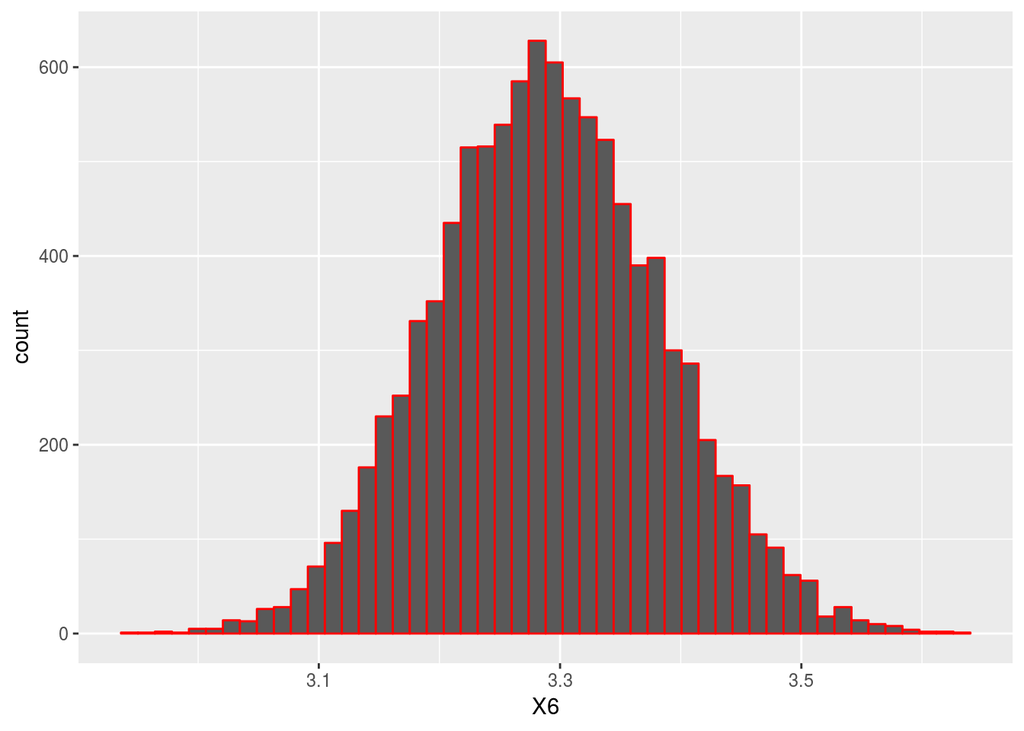

```r
graf2b
```

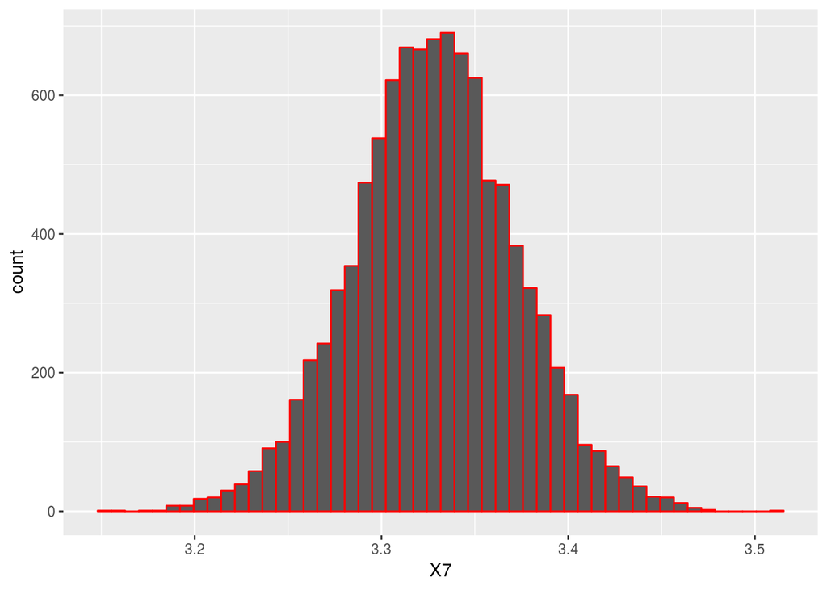

```r
graf3b
```

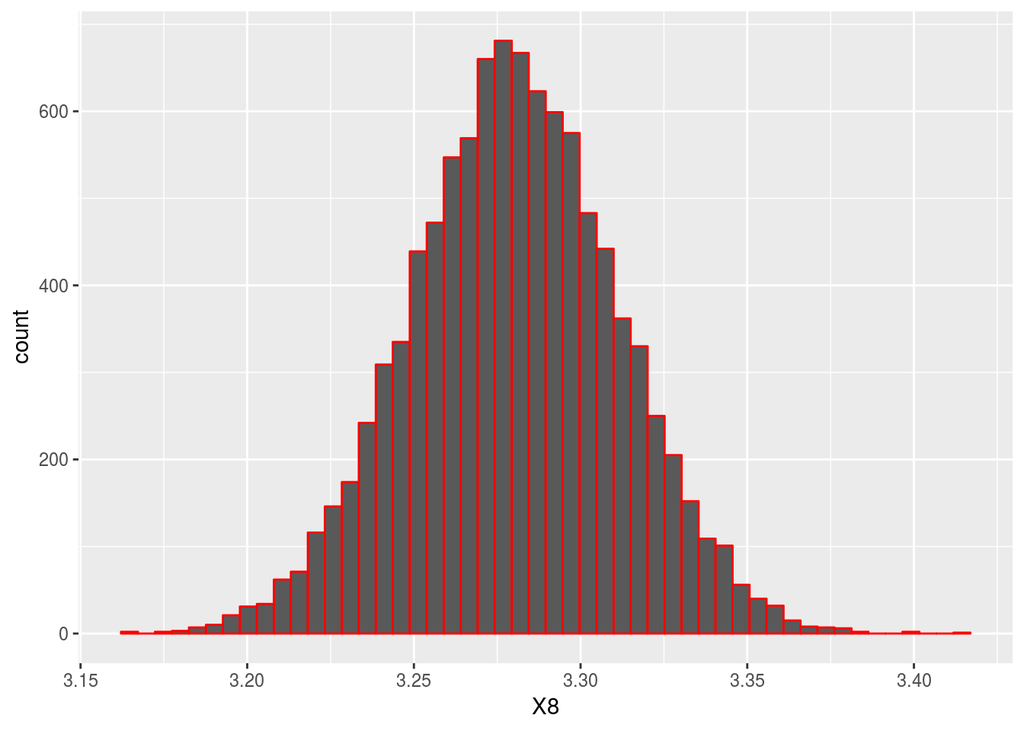

```r
graf4b
```

## Parte C

Para ver lo que ocurre ahora, tenemos que cambiar la distribucion de $x_{2}$ y mantener todo lo demas constante:

```r
set.seed(100)
reps=10000
betas=matrix(NA,nrow=reps,ncol=8)
beta0=2
beta1=2.5
beta2=1
n=c(50,100,500,1000)
for(j in 1:length(n)){
  x1<-rnorm(n[j],20,1)
  x2=runif(n[j],0,1)
  for(i in 1:reps){
    u<-rnorm(n[j],0,1)
    y=beta0+beta1*x1+beta2*x2+u
    model=lm(y~x1)
    betas[i,j]=model$coef[1]
    betas[i,j+4]=model$coef[2]

  }
  }
```

Y obtenemos la varianza y esperanza de de $\beta_{1}$ y $\beta_{2}$

```r
betas_df<-data.frame(betas)
apply(betas_df,2,mean)
```

```
##        X1        X2        X3        X4        X5        X6        X7
## 0.9569822 1.9695195 2.0941743 2.5933977 2.5754618 2.5257447 2.5205285
##        X8
## 2.4953669
```

```r
apply(betas_df,2,var)
```

```
##           X1           X2           X3           X4           X5
## 12.554640944  4.221489145  0.765931015  0.396059767  0.031096928
##           X6           X7           X8
##  0.010517813  0.001908195  0.000987609
```

Y graficamos con la nueva distribucion que sigue $x_{2}$

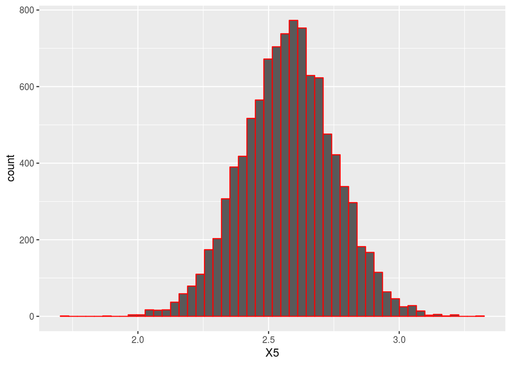

```r
graf1c<-ggplot(betas_df, aes(X5))+geom_histogram(col="red", bins=50)
graf2c<-ggplot(betas_df, aes(X6))+geom_histogram(col="red", bins=50)
graf3c<-ggplot(betas_df, aes(X7))+geom_histogram(col="red", bins=50)
graf4c<-ggplot(betas_df, aes(X8))+geom_histogram(col="red", bins=50)


graf1c
```

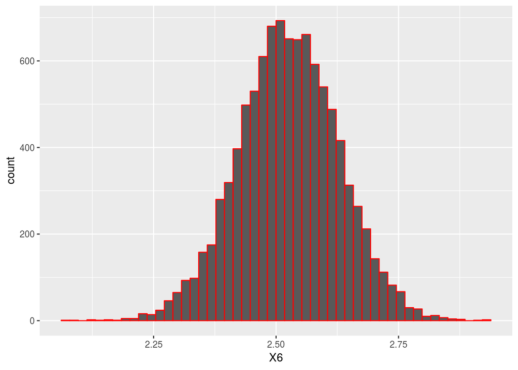

```r
graf2c
```

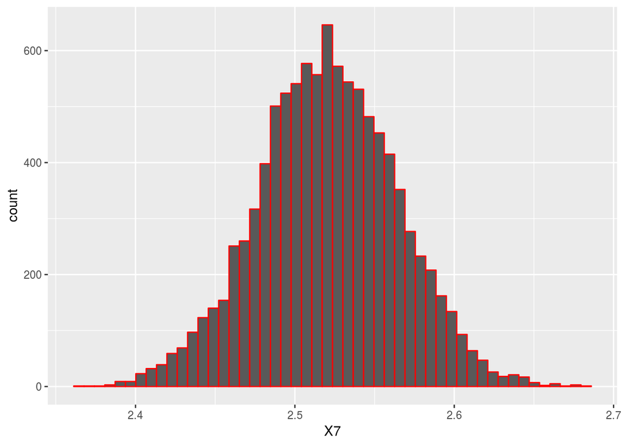

```r
graf3c
```

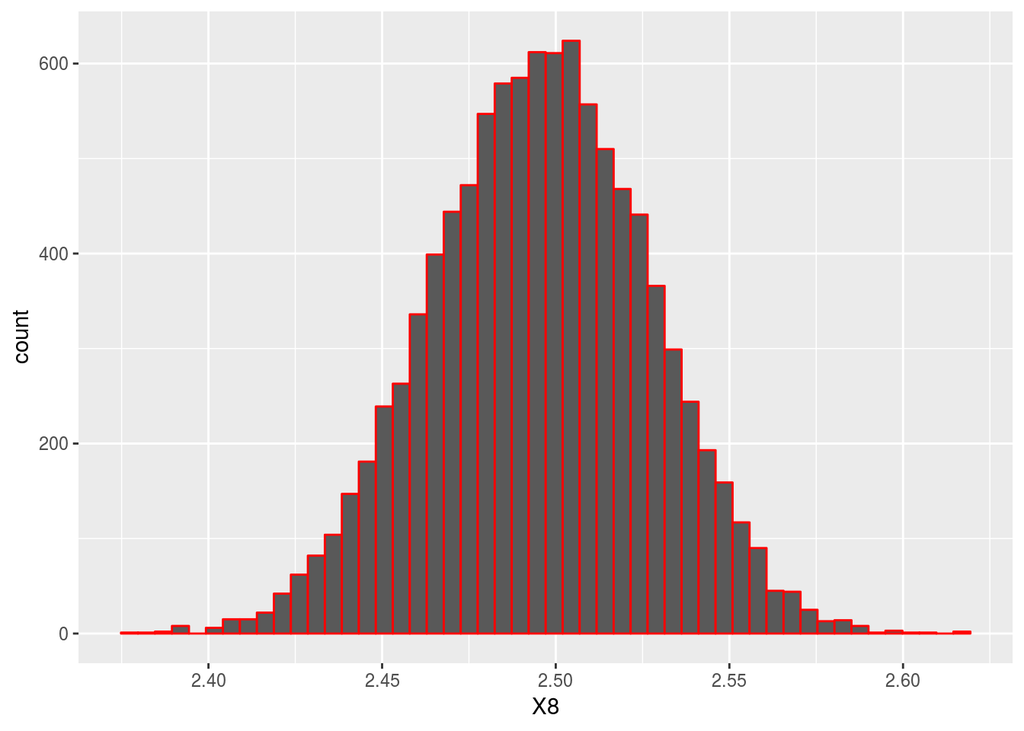

```r
graf4c
```

Este es un caso muy extraño donde al omitir la variable, pese a ser relevante, no se produce sesgo.